# Active Learning Literature

- [1] C.-C. Kao, T.-Y. Lee, P. Sen, and M.-Y. Liu, ‘Localization-Aware Active Learning for Object Detection’.
- [2] M. Menke, T. Wenzel, and A. Schwung, ‘Bridging the gap: Active learning for efficient domain adaptation in object detection’, Expert Systems with Applications, vol. 254, p. 124403, Nov. 2024, doi: 10.1016/j.eswa.2024.124403.
- [3] J. Lin et al., ‘Exploring Diversity-based Active Learning for 3D Object Detection in Autonomous Driving’, Oct. 22, 2024, arXiv: arXiv:2205.07708. doi: 10.48550/arXiv.2205.07708.
- [4] J. Schneegans, M. Bieshaar, and B. Sick, ‘A Practical Evaluation of Active Learning Approaches for Object Detection’.

### Common Strategies of Literature

- Sampling strategies follows usually two strategies: diversity and uncertainty. [2]
- Domain Discriminator: to predict the target domain likelihood of each sample. [2]
- Model agreement.[2] Model on the source, and a model on the source + unlabeled target data (SSL), calculate the agreement to identify regions of interest that exhibit divergence between two detectors. These regions can be used to select target images for active learning training.
- Uncertainty measurement of objects. Proposes to use the least confident boxes accumulated over the whole image to select releveant images for labelling. (Used for CAPTCHA recognition)
- Incorporate Loss functions at the Active Learning Pipeline.
- Teacher/Student networks. Pseudo-Labels and Semi-Supervised Learning (SSL). Adversarial-Learning.

## Actual context

our work is under the domain-adaptation object detection (DAOB)

**zero-shot active learning sample selection for one-class object detection.**

model-agnostic, based on dense feature selection of a froozen high-dense space (DINOV3).

Therefore, we propose an unsupervised sample selection that treats the latent space as a hyperesphere and leverages machine-learning techniques: clustering and OOD out-of-distribution to identify the most informative and diverse samples based on scene-level dense features. This approach may be extended to object-level feature analysis.

At the scene level, we use k-nearest neighbour (kNN) distance as a proxy for representativeness, capturing visual patterns such as water texture, luminosity, and scene composition through cosine similarity in the embedding space.

Given the characteristics of UAV drone imagery used for wildlife monitoring, we adopt SAHI (sliced-aided hyper inference) tiling strategy, wit patches of 640x640 to fine-tune a RT-DETR model with pre-trained weights.

```python
import sys
from pathlib import Path

project_root = Path.cwd().parent
sys.path.append(str(project_root / "src"))

from active_learning_fiftyone import compute_clustering_representativeness
```

### Compute clustering representativeness

### Compute Uniqueness

```python
### Import new dataset
dataset = fo.load_dataset("FLPLAN")

## our dataset has already the embeddings stored in its field
```

```python
from active_learning_fiftyone import compute_clustering_representativeness

# compute clustring representativeness
cluster_labels, centroids, embeddings_norm, sample_ids = compute_clustering_representativeness(
    dataset,
    embeddings_field = "full_embeddings",
    cluster_field  = "cluster_label",
    n_clusters    = 13,
    n_init    = 10,
    seed   = 42,
    max_iter = 500, # any kwargs of sklearn KNN
)
```

```
  Loading embeddings from field 'full_embeddings' ...
 100% |███████████████████| 83/83 [1.0s elapsed, 0s remaining, 81.2 samples/s]
  Loaded 83 embeddings, dim=1024
  Running KMeans (k=13, n_init=10, seed=42, extra={'max_iter': 500}) ...
  Cluster sizes: min=2  mean=6.4  max=11
  Empty clusters: 0 / 13
  Writing field 'cluster_label' to dataset ...
 100% |███████████████████| 83/83 [980.2ms elapsed, 0s remaining, 86.6 samples/s]
bum! Cluster labels saved to 'cluster_label'.
```

```python
from active_learning_fiftyone import compute_uniqueness_field

weighted_dists, sample_ids = compute_uniqueness_field(
    dataset,
    embeddings_field = "full_embeddings",
    uniqueness_field = "uniqueness_score",
    k                = 5,          # number of neighbours — now a parameter
    decay            = "exponential",  # "exponential", "linear", "power"
    decay_param      = 0.5,         # lambda for exponential, p for power, unused for linear
    save             = True,
    verbose          = True,
)
```

[output not shown]

[figure not shown]

# Last approach

Fixed weights: [0.9, 0.6, 0.3, 0.1] k=4 neighboors

Trying to improve this weighting on neighboors, I implement some weight decay families

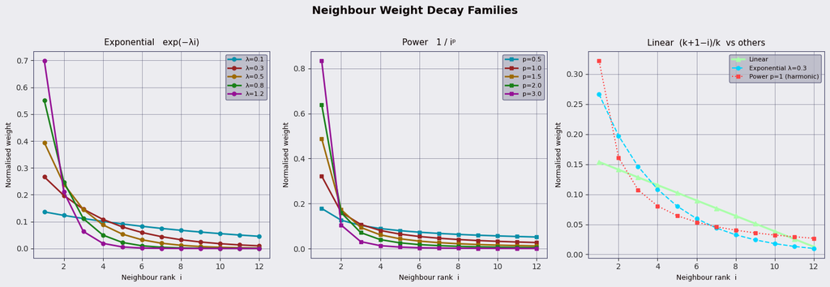

```
Computing uniqueness for N=83 embeddings, k=5 ...
  Linear                    mean=0.4498  std=0.1391  above 0.9: 2
  Exponential λ=0.5         mean=0.4376  std=0.1380  above 0.9: 2
  Exponential λ=0.8         mean=0.4199  std=0.1398  above 0.9: 2
  Power p=1 (harmonic)      mean=0.4373  std=0.1372  above 0.9: 2
  Power p=3                 mean=0.3837  std=0.1518  above 0.9: 1
```

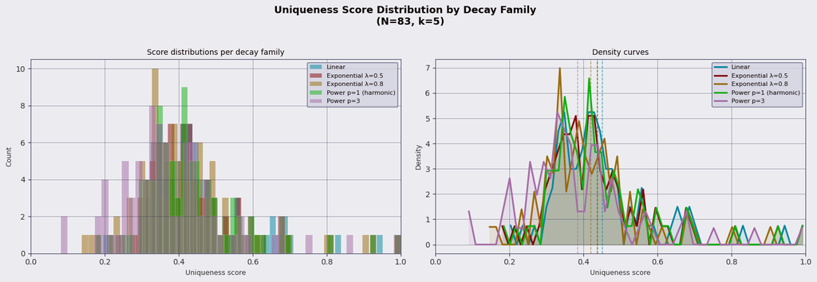

```python
from plots_helper import plot_uniqueness_landscape
```

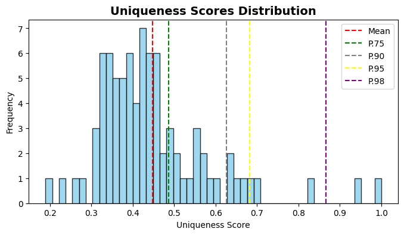

```
Loading embeddings and scores ...
  29% |█████--------------| 24/83 [237.3ms elapsed, 583.5ms remaining, 101.1 samples/s]
```

```
 100% |███████████████████| 83/83 [709.0ms elapsed, 0s remaining, 117.1 samples/s]
  N=83  |  score range [0.189, 1.000]
Computing PCA ...
Computing UMAP ...
Computing t-SNE ...
```

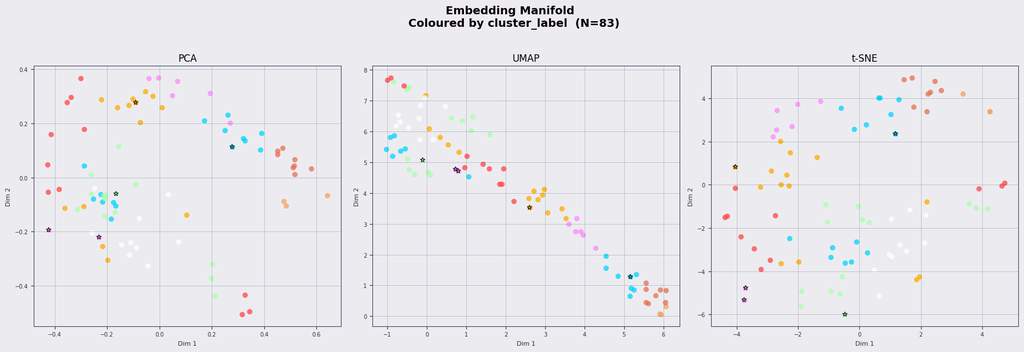

```python
session = fo.launch_app(dataset,
                        port=5151,
                        auto=False)
print(session.url)
```

```
Session launched. Run `session.show()` to open the App in a cell output.
http://localhost:5151/
```

# Scene-level vs Object-level

#### Dugong distribution size - bounding box

```
  57% |██████████|--------| 47/83 [956.4ms elapsed, 732.6ms remaining, 49.1 samples/s]
```

```
 100% |███████████████████| 83/83 [1.8s elapsed, 0s remaining, 46.4 samples/s]
Annotations   : 86
Width         : mean=116.1px  median=121.0px
Height        : mean=132.6px  median=130.0px
Area          : mean=14718px²  median=14349px²
```

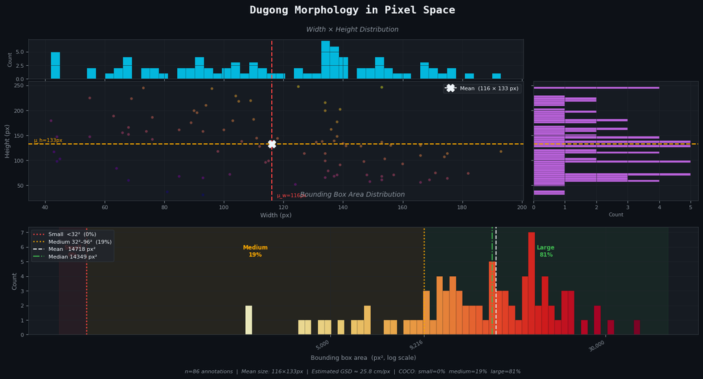

```python
fig, widths, heights, areas = plot_dugong_morphology_dashboard(
    dataset
)
```

# Why is important?

- Now, the overlap of our tiling should be at least 200 pixels, to avoid cutting dugongs in half. (640X640 with 200 overlap).
- Filtering tiles that are very small and therefore only contain a partially scene of the dugong.
- Most important, how many 28x28 Dinov3 embeddings composes a dugong object.

DInov3 resizes the image to a choosen standard size (here I am using 448x488) this means that our full-images (3000x4000) are resized to 448x448 and then extracted the features (embedding) for a scene level. Dinov3 uses a stride of 16, which for a image of 448/16 gives 28x28. My tiles are composed to 640x640, then they are interpolated to 448x488, than I am extracting the dense features from 28x28x1024 vectors. Here I am analysing the intra-token variability.

### Dense Feature Space - Plot

```python
dataset_fplan_patches = fo.load_dataset("flplanpatches")
```

```
  Image size (original): 640 x 640 px
  Resized to           : 448 x 448 px
  Token grid           : 28 x 28 = 784 tokens
  Bbox centre (orig)   : (505.5, 323.0) px
  Bbox centre (scaled) : (353.8, 226.1) px
  Reference token      : row=14, col=22  (flat idx=414)
  Total tokens         : 789  (1 CLS + 4 registers + 784 patch)
  Patch token shape    : (784, 1024)
```

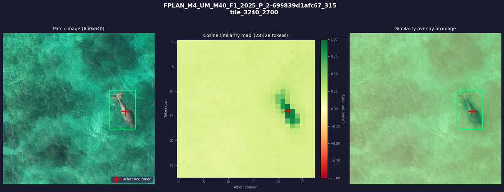

```
  Image size (original): 640 x 640 px
  Resized to           : 448 x 448 px
  Token grid           : 28 x 28 = 784 tokens
  Bbox centre (orig)   : (417.0, 416.5) px
  Bbox centre (scaled) : (291.9, 291.5) px
  Reference token      : row=18, col=18  (flat idx=522)
  Total tokens         : 789  (1 CLS + 4 registers + 784 patch)
  Patch token shape    : (784, 1024)
```

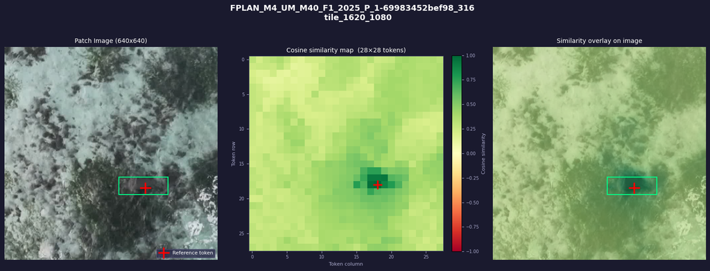

```
  Image size (original): 640 x 640 px
  Resized to           : 448 x 448 px
  Token grid           : 28 x 28 = 784 tokens
  Bbox centre (orig)   : (269.0, 262.5) px
  Bbox centre (scaled) : (188.3, 183.8) px
  Reference token      : row=11, col=11  (flat idx=319)
  Total tokens         : 789  (1 CLS + 4 registers + 784 patch)
  Patch token shape    : (784, 1024)
```

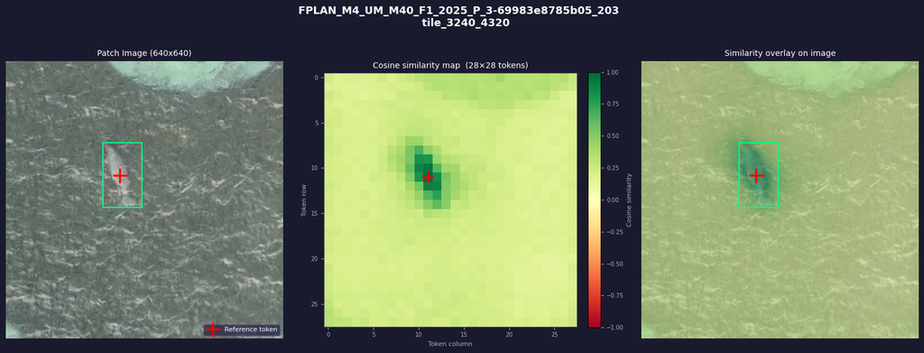

```
  Image size (original): 640 x 640 px
  Resized to           : 448 x 448 px
  Token grid           : 28 x 28 = 784 tokens
  Bbox centre (orig)   : (367.5, 377.5) px
  Bbox centre (scaled) : (257.2, 264.2) px
  Reference token      : row=16, col=16  (flat idx=464)
  Total tokens         : 789  (1 CLS + 4 registers + 784 patch)
  Patch token shape    : (784, 1024)
```

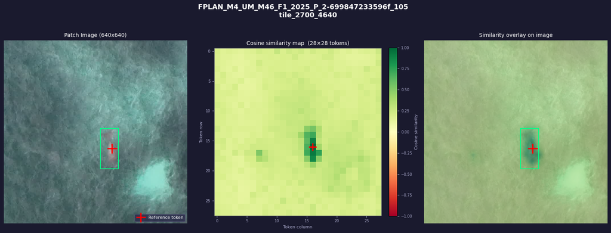

```
  Image size (original): 640 x 640 px
  Resized to           : 448 x 448 px
  Token grid           : 28 x 28 = 784 tokens
  Bbox centre (orig)   : (231.5, 204.5) px
  Bbox centre (scaled) : (162.0, 143.1) px
  Reference token      : row=8, col=10  (flat idx=234)
  Total tokens         : 789  (1 CLS + 4 registers + 784 patch)
  Patch token shape    : (784, 1024)
```

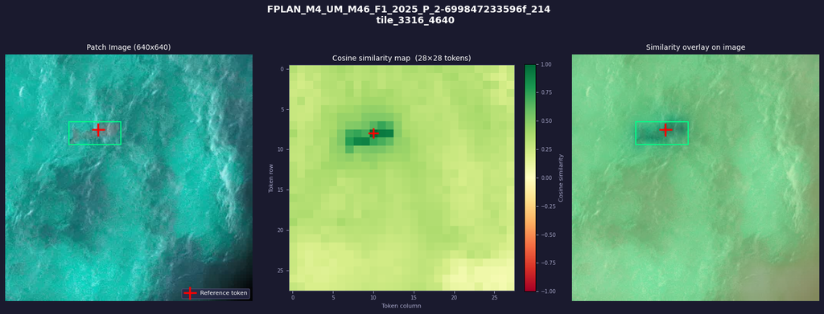

# Plot dimensionality reduction of objects

```python
dataset_flplan_patches = fo.load_dataset("flplan200")
```

```python
Path(dataset_flplan_patches.first()['source_image']).stem
```

```
'FPLAN_M4_UM_M13_F1_2025_P_1-6973989e86e75_363'
```

```python
for sample in dataset_flplan_patches.iter_samples(progress=True):
    sample['flight_name'] = Path(sample['source_image']).stem.split('-')[0].split('_')[3]
    sample.save()
```

```
 100% |█████████████████| 328/328 [23.2s elapsed, 0s remaining, 26.0 samples/s]
```

```python
dataset_flplan_patches.count_values('flight_name')
```

```
{'M48': 28,
 'M33': 32,
 'M4': 8,
 'M35': 36,
 'M40': 81,
 'M15': 40,
 'M46': 61,
 'M13': 42}
```

```python
from plots_helper import plot_patch_embedding_landscape
```

```
Loading patch embeddings ...
 100% |█████████████████| 328/328 [6.8s elapsed, 0s remaining, 78.0 samples/s]
  N=250 dugong patch embeddings  dim=1024
Computing PCA ...
Computing UMAP ...
Computing t-SNE ...
```

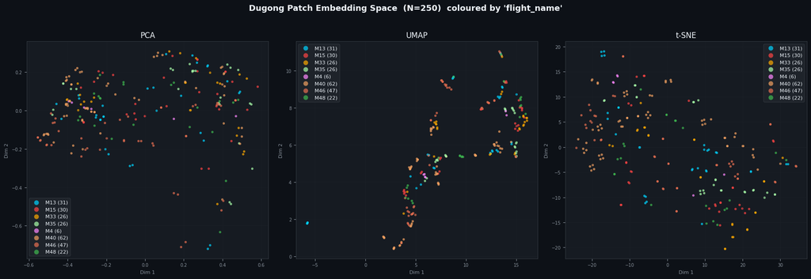

```python
fig, dict = plot_patch_embedding_landscape(
    dataset_flplan_patches,
    embeddings_field = 'patch_embeddings',
    color_field         = 'flight_name',
    umap_neighbors = 7,
    tsne_perplexity = 30.0,
    seed          = 42,
)
```

### Clustering and Uniqueness

```python
from plots_helper import compute_clustering_detections
```

```python
cluster_labels, centroids, embs, det_ids = compute_clustering_detections(
    dataset_flplan_patches,
    embeddings_field = "ground_truth.detections.patch_embeddings",
    cluster_field    = "ground_truth.detections.patch_cluster_label",
    n_clusters       = 10,
    seed             = 42,
    verbose          = True,
)
```

```
  Loading detection embeddings from 'ground_truth.detections.patch_embeddings' ...
   3% |-----------------|  10/328 [342.0ms elapsed, 10.9s remaining, 29.2 samples/s]
```

```
 100% |█████████████████| 328/328 [6.2s elapsed, 0s remaining, 73.3 samples/s]
  Loaded 250 detection embeddings  dim=1024
  Running KMeans (k=10, n_init=10, seed=42) ...
  Cluster sizes: min=7  mean=25.0  max=49
  Empty clusters: 0 / 10
  Writing cluster labels to 'ground_truth.detections.patch_cluster_label' ...
 100% |█████████████████| 328/328 [24.1s elapsed, 0s remaining, 27.2 samples/s]
✓ Cluster labels saved to 'ground_truth.detections.patch_cluster_label'.
```

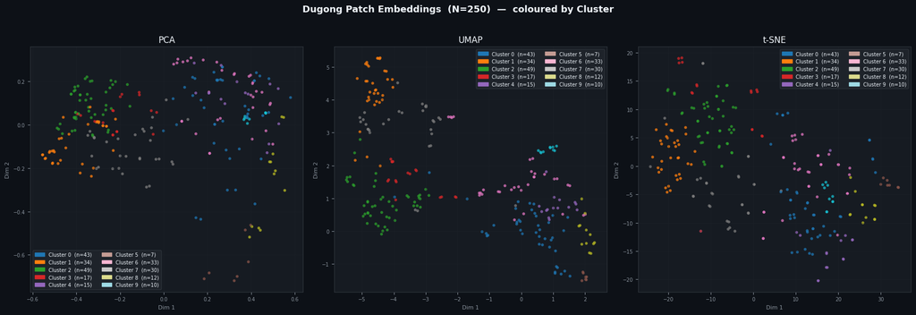

# Token-to Token similarity

```
Dugong token grid : 7 rows × 4 cols = 28 tokens  dim=1024
Subplot grid      : 7 × 4
Similarity matrix : (28, 28)  [min=0.416  max=1.000]
```

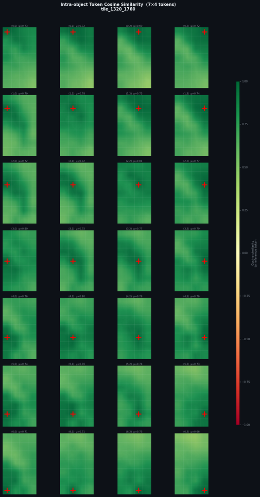